# A guide to testing differences between groups with integer data

Ib Thorsgaard Jensen

24/6/2021

This guide describes how to choose an appropriate model obtain tests for differences between groups of counts. As an example we consider the following example with simulated data.

```r
head(Simulations, n = 18)
```

```
##     group Count
##  1:     1    57
##  2:     2    30
##  3:     3     8
##  4:     4    51
##  5:     5    20
##  6:     6     2
##  7:     7     6
##  8:     8    74
##  9:     9    72
## 10:     1    43
## 11:     2    29
## 12:     3    40
## 13:     4    34
## 14:     5    40
## 15:     6     0
## 16:     7     4
## 17:     8    27
## 18:     9    60
```

We have nine groups, each with 15 observations. We pick the first group as the reference group (the group that we compare the other groups to. For e.g. nodule-count data this would usually be the wildtype). Because the data is simulated we know the true values of the parameters. For real data these are always unknown. Group 1-5 all have a mean of 30, group 6 and 7 have mean of 5 and group 8 and 9 have a mean of 50. That is group 2-5 are not different from the reference group, group 6-7 have a large difference (factor of 6) and group 8-9 have a relatively modest difference (a factor of 5/3).

## Poisson regression is insufficient

The usual first choice for modeling count-data is a poisson regression, so we try that first.

```r
g <- glm(Count~group, data = Simulations, family = poisson())
summary(g)
```

```
##
## Call:
## glm(formula = Count ~ group, family = poisson(), data = Simulations)
##
## Deviance Residuals:
##     Min       1Q   Median       3Q      Max
## -6.4199  -1.7225  -0.2557   1.0576   6.7907
##
## Coefficients:
##             Estimate Std. Error z value Pr(>|z|)
## (Intercept)  3.66014    0.04142  88.375  < 2e-16 ***
## group2      -0.34959    0.06441  -5.428 5.70e-08 ***
## group3      -0.32082    0.06387  -5.023 5.09e-07 ***
## group4      -0.13574    0.06066  -2.238  0.02525 *
## group5      -0.19858    0.06170  -3.218  0.00129 **
## group6      -2.32514    0.13878 -16.754  < 2e-16 ***
## group7      -2.14868    0.12815 -16.768  < 2e-16 ***
## group8       0.34962    0.05408   6.465 1.01e-10 ***
## group9       0.26645    0.05504   4.841 1.29e-06 ***
## ---
## Signif. codes:  0 '***' 0.001 '**' 0.01 '*' 0.05 '.' 0.1 ' ' 1
##
## (Dispersion parameter for poisson family taken to be 1)
##
##     Null deviance: 2216.79  on 134  degrees of freedom
## Residual deviance:  680.07  on 126  degrees of freedom
## AIC: 1348.4
##
## Number of Fisher Scoring iterations: 5
```

We see that all groups are significantly different from the reference group, but as we noted earlier only group 6-9 are different. Clearly a poisson regression is not appropriate here. So what is the problem? First we check the estimated fold-changes compared to the reference group

```r
exp(coef(summary(g))[,1])
```

```
## (Intercept)      group2      group3      group4      group5      group6
## 38.86666667  0.70497427  0.72555746  0.87307033  0.81989708  0.09777015
##      group7      group8      group9
##  0.11663808  1.41852487  1.30531732
```

We see that the parameter estimates are fairly close to the true values (or at least as close as we’re likely to get with 15 observations; the intercept is the mean of the reference group). So the problem is not with the parameter estimates.

Another possibilty is the mean-variance structure. A poisson regression assumes that the mean and variance are identical wihtin each group. We can check this assumption

```r
(mv <- Simulations[, list(Mean=mean(Count), Variance=var(Count)), by = group])
```

```
##    group      Mean  Variance
## 1:     1 38.866667 241.98095
## 2:     2 27.400000 252.25714
## 3:     3 28.200000  96.02857
## 4:     4 33.933333 167.06667
## 5:     5 31.866667 140.40952
## 6:     6  3.800000   9.60000
## 7:     7  4.533333  12.55238
## 8:     8 55.133333 558.26667
## 9:     9 50.733333 232.92381
```

We clearly have overdispersed data (the variance is greater than the mean). Now the results from above makes sense, since the poisson regression underestimates the variances, and thus the standard error is too small. This can cause false positives.

## Dealing with overdispersed data

Overdispersion is common for nodule-count data. There are two commonly used options for this type of data, a negative binomial regression and a quasi-poisson regression. They make different assumptions about the mean-variance structure, so which can serve as model validation for a given dataset. The quasi-poisson regression asumes the variance is proportional to the mean, so we have
$$\sigma^2 = \phi\mu$$
for some $\phi>0$, which is treated as a nuisance parameter. That is, it is a feature of the dataset that must be taken into account, but it is not of interest and probably doesn’t say anything useful about the population as a whole. For a negative binomial regression we assume the relation
$$\sigma^2 = \mu + \frac{\mu^2}{\theta}.$$
Here $\theta$ is treated as a proper parameter which says something about the general population.

The best choice of model comes down to whether the mean-variance structure of the dataset is best captured as a linear or quadratic relation. We check the simulated dataset

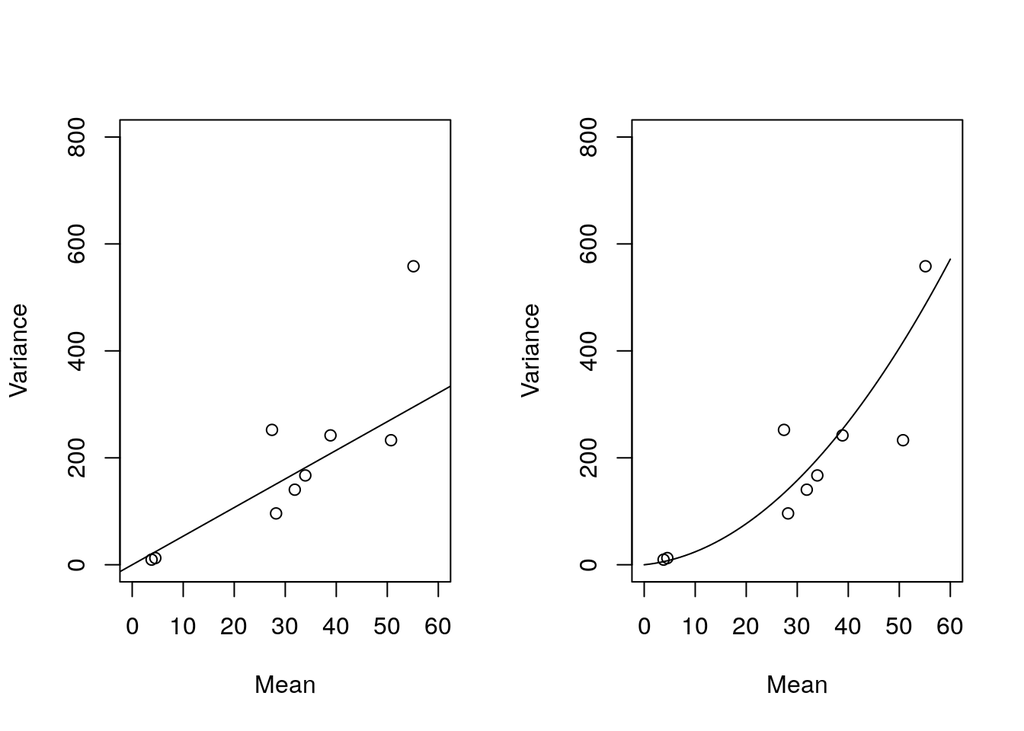

```r
g2 <- glm(Count~group, family = quasipoisson, data = Simulations)
d <- summary(g2)$disp
par(mfrow=c(1,2))
plot(mv$Mean, mv$Variance, ylim = c(0,800), xlim = c(0,60), xlab = "Mean", ylab = "Variance"); abline(0, d)
g3 <- glm.nb(Count~group, data = Simulations)
x <- 0:60
plot(mv$Mean, mv$Variance, ylim = c(0,800), xlim = c(0,60), xlab = "Mean", ylab = "Variance"); points(x, x + x^2/g3$theta, type = "l")
```

Apart from a single outlier they both seem to fit fairly well (the last point fro quasi-poisson and the second to last for the negative binomial). In such cases it is generally recommended to pick quasi-poisson, since it is more robust to violations of its assumption. We check the estimates and adjust the $p$-values.

```r
data.frame(coef(summary(g2)), P_adjusted = p.adjust(coef(summary(g2))[,4], method = "holm"))
```

```
##               Estimate Std..Error    t.value     Pr...t..   P_adjusted
## (Intercept)  3.6601370 0.09582411 38.1964117 3.896527e-71 3.506874e-70
## group2      -0.3495940 0.14902086 -2.3459399 2.054035e-02 1.027018e-01
## group3      -0.3208150 0.14777589 -2.1709564 3.180875e-02 1.272350e-01
## group4      -0.1357392 0.14035478 -0.9671147 3.353393e-01 3.353393e-01
## group5      -0.1985765 0.14276394 -1.3909427 1.666943e-01 3.333885e-01
## group6      -2.3251359 0.32109038 -7.2413752 3.879037e-11 3.012982e-10
## group7      -2.1486795 0.29649050 -7.2470433 3.766227e-11 3.012982e-10
## group8       0.3496175 0.12512139  2.7942264 6.016025e-03 3.609615e-02
## group9       0.2664462 0.12734505  2.0923166 3.841709e-02 1.272350e-01
```

We see that only group 6-8 are significantly different from the reference group. This means that we get no false positives and only one false negative. Group 8 and 9 are relatively close to the reference group, so cannot necessarily expect to detect them with only 15 observations per group.

We check the results from the negative binomial

```r
data.frame(coef(summary(g3)), P_adjusted = p.adjust(coef(summary(g3))[,4], method = "holm"))
```

```
##               Estimate Std..Error     z.value      Pr...z..    P_adjusted
## (Intercept)  3.6601370  0.1057712  34.6042747 2.178811e-262 1.960930e-261
## group2      -0.3495940  0.1519636  -2.3005113  2.141927e-02  1.084236e-01
## group3      -0.3208150  0.1517363  -2.1142928  3.449026e-02  1.379611e-01
## group4      -0.1357392  0.1504144  -0.9024349  3.668259e-01  3.760164e-01
## group5      -0.1985765  0.1508373  -1.3164943  1.880082e-01  3.760164e-01
## group6      -2.3251359  0.1954577 -11.8958536  1.243747e-32  9.949980e-32
## group7      -2.1486795  0.1880578 -11.4256350  3.113712e-30  2.179598e-29
## group8       0.3496175  0.1478818   2.3641682  1.807060e-02  1.084236e-01
## group9       0.2664462  0.1482360   1.7974461  7.226483e-02  2.167945e-01
```

Here we also get no false positives, but we get two false negatives.

The above data was simulated from a quasi poisson distribution, so it is unsurprising that it yielded a better fit. In the interest of fairness we fit both models to data from a negative binomial distribution as well.

```r
(mv <- SimulationsNB[, list(Mean=mean(Count), Variance=var(Count)), by = group])
```

```
##    group      Mean   Variance
## 1:     1 41.466667  792.12381
## 2:     2 23.333333  246.09524
## 3:     3 25.400000  270.40000
## 4:     4 31.066667  159.92381
## 5:     5 32.000000  510.00000
## 6:     6  3.533333   12.12381
## 7:     7  6.866667   30.98095
## 8:     8 79.933333 2154.06667
## 9:     9 48.533333 2236.83810
```

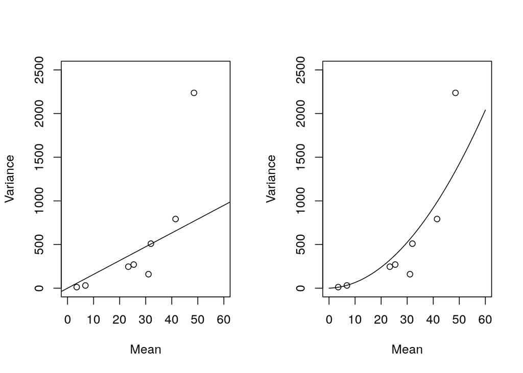

```r
g4 <- glm(Count~group, family = quasipoisson, data = SimulationsNB)
d <- summary(g4)$disp
par(mfrow=c(1,2))
plot(mv$Mean, mv$Variance, ylim = c(0,2500), xlim = c(0,60), xlab = "Mean", ylab = "Variance"); abline(0, d)
g5 <- glm.nb(Count~group, data = SimulationsNB)
x <- 0:60
plot(mv$Mean, mv$Variance, ylim = c(0,2500), xlim = c(0,60), xlab = "Mean", ylab = "Variance"); points(x, x + x^2/g5$theta, type = "l")
```

It does seem like the negative binomial is a better fit, but if we didn’t know the distribution, a linear relationship with an outlier could not be ruled out.

## The consequences choosing the wrong model

We see in the above section that it can be difficult to judge which model is the most appropriate based on the mean-variance relationship. To answer this question, 10000 simulations of a quasi-poisson distribution and a negative binomal were run. Below we see the results of applying different regression procedures to each.

```r
qpsims[,list(power = mean(Power), FP = sum(FDR)), by = Model]
```

```
##                Model    power    FP
## 1:           poisson 0.998875 11452
## 2:      quasipoisson 0.947725   486
## 3: Negative Binomial 0.911975   502
```

```r
NBsims[,list(power = mean(Power), FP = sum(FDR)), by = Model]
```

```
##                Model    power    FP
## 1:           poisson 0.953425 24731
## 2:      quasipoisson 0.545325   324
## 3: Negative Binomial 0.604025   618
```

Here “power” refers to statistical power, the proportion of true differences detected, and “FP” is the number of false discoveries over all 10000 runs. From the results we see that a quasi-poisson regression is generally the safest choice with only a minor loss in power even in situations where it is not the optimal.

There is an exception to this. If we have a highly overdispersed negative binomial distribution, a quasi-poisson regression may fail to maintain statistical power. Below we see an example.

```r
g7 <- glm(Count~group, family = quasipoisson, data = SimulationsNB2)
summary(g7)
```

```
##
## Call:
## glm(formula = Count ~ group, family = quasipoisson, data = SimulationsNB2)
##
## Deviance Residuals:
##     Min       1Q   Median       3Q      Max
## -10.532   -7.498   -4.017    0.331   40.661
##
## Coefficients:
##             Estimate Std. Error t value Pr(>|t|)
## (Intercept)  3.82864    0.42465   9.016 2.68e-15 ***
## group2      -0.49882    0.69085  -0.722    0.472
## group3      -0.06126    0.60995  -0.100    0.920
## group4       0.04672    0.59365   0.079    0.937
## group5      -0.09894    0.61596  -0.161    0.873
## group6      -2.27401    1.39024  -1.636    0.104
## group7      -1.74090    1.09937  -1.584    0.116
## group8       0.18714    0.57434   0.326    0.745
## group9      -0.31809    0.65435  -0.486    0.628
## ---
## Signif. codes:  0 '***' 0.001 '**' 0.01 '*' 0.05 '.' 0.1 ' ' 1
##
## (Dispersion parameter for quasipoisson family taken to be 124.4234)
##
##     Null deviance: 11185.5  on 134  degrees of freedom
## Residual deviance:  9775.3  on 126  degrees of freedom
## AIC: NA
##
## Number of Fisher Scoring iterations: 7
```

We see that no group is significantly different, despite group 6-9 all having different means to the reference group. We also see that the dispersion parameter is estimated to be nearly 125. This is very high and may be a way to detect when this case arises.

## Conclusion

If a quasi-poisson regression returns a very large estiamte of the overdispersion parameter, and the mean-variance structure looks quadratic, a negative binomial regression is likely to be the optimal choice. Otherwise a quasi-poisson regression is the safest option.